# Reduced sparse monkey PK study design simulations

NAMLink

## Purpose

This workflow implements a two-gate decision analysis for using a priori PBPK and a reduced sparse monkey PK study to support monoclonal antibody PK characterization before human trial initiation.

**Gate 1: a priori adequacy.** The a priori monkey prediction is compared with observed monkey PK exposure from the retrospective dataset. A molecule triggers a reduced monkey PK study if at least one a priori monkey AUC fold-error is outside the prespecified 2-fold interval.

**Gate 2: reduced sparse-study adequacy.** For triggered molecules only, the top-down monkey model is treated as the retrospective reference for true monkey PK. The analysis asks whether a reduced sparse monkey PK study with small sample size can recover the top-down population exposure within 2-fold.

Manuscript note: this analysis intentionally does not bias-correct the a priori model. Bias is part of Gate 1. Once Gate 1 fails, the reduced study design is evaluated against the observed-informed/top-down monkey reference, not against the a priori model.

```r
rm(list = ls())

suppressPackageStartupMessages({
  library(tidyverse)
  library(rxode2)
  library(knitr)
  library(kableExtra)
})

set.seed(20260628)

N_VIRTUAL <- 100L
PARAMETER_CV <- 0.30
FOLD_ACCEPTANCE <- 2
AUC_END_H <- 28 * 24
N_SIM <- 1000L
N_PER_GROUP <- 2:5

STUDY_DOSES <- c(0.3, 3, 10)
DESIGN_DOSES <- list(
  `2 dose groups` = c(0.3, 10),
  `3 dose groups` = c(0.3, 3, 10)
)

SPARSE_TIME_H <- c(0.25, 1, 2, 4, 8, 1, 2, 6, 10, 14, 21, 28) *
  c(rep(1, 5), rep(24, 7))
SPARSE_TIME_H <- sort(unique(SPARSE_TIME_H))
RICH_TIME_H <- c(0.25, 0.5, seq(1, AUC_END_H, by = 1))

study_dir <- if (basename(normalizePath(".", winslash = "/", mustWork = TRUE)) ==
                 "05_StudySimulations") {
  normalizePath(".", winslash = "/", mustWork = TRUE)
} else {
  normalizePath("05_StudySimulations", winslash = "/", mustWork = TRUE)
}
project_dir <- normalizePath(file.path(study_dir, ".."), winslash = "/", mustWork = TRUE)
topdown_dir <- file.path(project_dir, "04_TopDown", "SimsOutputs")
data_dir <- file.path(project_dir, "01_Data", "Monkey")
output_root <- file.path(study_dir, "SimsOutputs")
figure_dir <- file.path(output_root, "Figures")
table_dir <- file.path(output_root, "Tables")
walk(c(output_root, figure_dir, table_dir), dir.create,
     recursive = TRUE, showWarnings = FALSE)

STUDY_THEME <- theme_bw(base_size = 15) +
  theme(
    legend.position = "bottom",
    legend.text = element_text(size = 13),
    plot.title = element_text(face = "bold", size = 18),
    plot.subtitle = element_text(size = 13),
    axis.title = element_text(face = "bold", size = 15),
    axis.text = element_text(size = 12),
    strip.text = element_text(face = "bold", size = 13),
    panel.grid.minor = element_blank()
  )

make_lognormal <- function(u, typical, cv) {
  sdlog <- sqrt(log1p(cv^2))
  qlnorm(u, meanlog = log(typical), sdlog = sdlog)
}

random_quantiles <- function(n, p) {
  matrix(runif(n * p), nrow = n, ncol = p)
}

conc_nm_to_ug_ml <- function(conc_nm, mw_g_mol) {
  as.numeric(conc_nm) * as.numeric(mw_g_mol) / 1e6
}

dose_mgkg_to_nmolkg <- function(dose_mgkg, mw_g_mol) {
  as.numeric(dose_mgkg) * 1e6 / as.numeric(mw_g_mol)
}

linup_logdown_auc <- function(time_h, concentration) {
  keep <- is.finite(time_h) & is.finite(concentration) & concentration >= 0
  time_h <- time_h[keep]
  concentration <- concentration[keep]
  ord <- order(time_h)
  time_h <- time_h[ord]
  concentration <- concentration[ord]
  if (length(time_h) < 2L) return(NA_real_)

  dt <- diff(time_h)
  c1 <- head(concentration, -1)
  c2 <- tail(concentration, -1)
  declining <- c2 < c1 & c1 > 0 & c2 > 0
  intervals <- dt * (c1 + c2) / 2
  intervals[declining] <-
    dt[declining] * (c1[declining] - c2[declining]) /
    log(c1[declining] / c2[declining])
  sum(intervals)
}

geometric_mean <- function(x) {
  x <- x[is.finite(x) & x > 0]
  exp(mean(log(x)))
}

within_fold <- function(estimate, reference, fold = FOLD_ACCEPTANCE) {
  ratio <- estimate / reference
  is.finite(ratio) && ratio >= 1 / fold && ratio <= fold
}
```

## Gate 1: a priori adequacy screen

The a priori adequacy screen uses the observed monkey fold-error table from the manuscript. Molecules with at least one a priori AUC fold-error outside 0.5-2.0 are the molecules for which a reduced monkey PK study would be triggered.

```r
gate1_fold_error <- tribble(
  ~Drug, ~Observed_dose_mgkg, ~APriori_Cmax_FE, ~Topdown_Cmax_FE, ~APriori_AUC_FE, ~Topdown_AUC_FE,
  "Adalimumab",    3,   1.21, 0.99, 1.22, 1.20,
  "Atezolizumab",  0.5, 1.42, 1.30, 2.27, 1.70,
  "Atezolizumab",  5,   1.09, 0.99, 1.11, 1.19,
  "Atezolizumab", 20,   0.86, 0.78, 0.87, 0.96,
  "Avelumab",      5,   1.30, 0.96, 2.80, 1.20,
  "Bevacizumab",   4,   1.14, 0.89, 0.64, 0.71,
  "Bevacizumab",   5,   1.35, 1.08, 1.48, 1.60,
  "Golimumab",     3,   0.80, 1.00, 1.00, 1.21,
  "Nivolumab",     1,   0.97, 1.27, 0.62, 1.34,
  "Nivolumab",    10,   0.74, 0.73, 0.49, 0.96,
  "Pembrolizumab", 0.3, 0.40, 0.39, 2.39, 0.87,
  "Pembrolizumab", 3,   0.99, 0.95, 2.88, 1.01,
  "Pembrolizumab",30,   1.05, 0.97, 3.23, 1.08,
  "Tocilizumab",  10,   1.06, 0.98, 1.80, 1.00
) %>%
  mutate(
    APriori_AUC_within_2fold =
      APriori_AUC_FE >= 1 / FOLD_ACCEPTANCE &
      APriori_AUC_FE <= FOLD_ACCEPTANCE,
    Trigger_reduced_PK = !APriori_AUC_within_2fold
  )

triggered_molecules <- gate1_fold_error %>%
  group_by(Drug) %>%
  summarise(
    Trigger_reduced_PK = any(Trigger_reduced_PK),
    Triggering_doses = paste(Observed_dose_mgkg[Trigger_reduced_PK],
                             collapse = ", "),
    .groups = "drop"
  ) %>%
  filter(Trigger_reduced_PK) %>%
  pull(Drug)

gate1_summary <- gate1_fold_error %>%
  group_by(Drug) %>%
  summarise(
    AUC_dose_levels = n(),
    AUC_levels_outside_2fold = sum(Trigger_reduced_PK),
    Trigger_reduced_PK = any(Trigger_reduced_PK),
    Triggering_doses_mgkg =
      paste(Observed_dose_mgkg[Trigger_reduced_PK], collapse = ", "),
    .groups = "drop"
  )

write.csv(
  gate1_fold_error,
  file.path(table_dir, "Gate1_monkey_apriori_fold_error_screen.csv"),
  row.names = FALSE
)
write.csv(
  gate1_summary,
  file.path(table_dir, "Gate1_triggered_molecules.csv"),
  row.names = FALSE
)

gate1_summary %>%
  kable(
    digits = 3,
    caption = paste0(
      "Gate 1 a priori adequacy screen. A reduced sparse monkey PK study is ",
      "triggered when any a priori monkey AUC fold-error is outside ",
      "0.5-", FOLD_ACCEPTANCE, "."
    )
  ) %>%
  kable_styling(bootstrap_options = c("striped", "condensed"),
                full_width = FALSE)
```

Gate 1 a priori adequacy screen. A reduced sparse monkey PK study is triggered when any a priori monkey AUC fold-error is outside 0.5-2.

| Drug | AUC_dose_levels | AUC_levels_outside_2fold | Trigger_reduced_PK | Triggering_doses_mgkg |
| --- | --- | --- | --- | --- |
| Adalimumab | 1 | 0 | FALSE |  |
| Atezolizumab | 3 | 1 | TRUE | 0.5, 5, 20 |
| Avelumab | 1 | 1 | TRUE | 5 |
| Bevacizumab | 2 | 0 | FALSE |  |
| Golimumab | 1 | 0 | FALSE |  |
| Nivolumab | 2 | 1 | TRUE | 1, 10 |
| Pembrolizumab | 3 | 3 | TRUE | 0.3, 3, 30 |
| Tocilizumab | 1 | 0 | FALSE |  |

Manuscript note: the triggered molecules are Atezolizumab, Avelumab, Nivolumab, Pembrolizumab. These are the molecules carried forward into the reduced-study design simulation.

## Build top-down reference population

The top-down monkey model is treated as the retrospective reference for true monkey PK among Gate 1-triggered molecules. This avoids circularity: the a priori model determines whether a reduced study is needed, but the reduced study is evaluated against an observed-informed monkey reference.

```r
mabs_for_design <- triggered_molecules

mw_lookup <- read.csv(
  file.path(data_dir, "mAb_data_clean.csv"),
  stringsAsFactors = FALSE,
  check.names = FALSE
) %>%
  transmute(Drug = Molecule, MW = as.numeric(`Molecular.Weight`)) %>%
  filter(Drug %in% mabs_for_design, is.finite(MW), MW > 0) %>%
  group_by(Drug) %>%
  summarise(MW = median(MW), .groups = "drop")

topdown_processed <- readRDS(
  file.path(topdown_dir, "TopDownTMDD_Run4_processed_Monkey.rds")
)

final_parameters <- topdown_processed$fit_summary %>%
  filter(
    Run == "Run4_CL_Vc_Q_Vp_fixed_TMDD",
    Molecule %in% mabs_for_design
  ) %>%
  transmute(
    Drug = Molecule,
    Rtot_nM,
    kdeg_h,
    kint_h,
    Kss_nM,
    CL_L_h_kg,
    Vc_L_kg,
    Q_L_h_kg,
    Vp_L_kg
  ) %>%
  left_join(mw_lookup, by = "Drug") %>%
  relocate(MW, .after = Drug)

required_parameter_columns <- c(
  "Drug", "MW", "Rtot_nM", "kdeg_h", "kint_h", "Kss_nM",
  "CL_L_h_kg", "Vc_L_kg", "Q_L_h_kg", "Vp_L_kg"
)
missing_parameter_columns <- setdiff(required_parameter_columns, names(final_parameters))
if (length(missing_parameter_columns) > 0L) {
  stop("Missing top-down parameters: ", paste(missing_parameter_columns, collapse = ", "))
}
stopifnot(
  setequal(final_parameters$Drug, mabs_for_design),
  all(is.finite(unlist(final_parameters[required_parameter_columns[-1]]))),
  all(unlist(final_parameters[required_parameter_columns[-1]]) > 0)
)

topdown_parameter_names <- c(
  "Rtot_nM", "kdeg_h", "kint_h", "Kss_nM",
  "CL_L_h_kg", "Vc_L_kg", "Q_L_h_kg", "Vp_L_kg"
)

parameter_draws <- map_dfr(mabs_for_design, function(drug) {
  medians <- final_parameters %>% filter(Drug == drug)
  quantile_matrix <- random_quantiles(N_VIRTUAL, length(topdown_parameter_names))
  draws <- map2_dfc(
    seq_along(topdown_parameter_names),
    topdown_parameter_names,
    ~ make_lognormal(
      quantile_matrix[, .x],
      typical = medians[[.y]],
      cv = PARAMETER_CV
    )
  )
  names(draws) <- topdown_parameter_names

  tibble(
    Drug = drug,
    MW = medians$MW,
    IndividualId = seq_len(N_VIRTUAL)
  ) %>%
    bind_cols(draws)
})

write.csv(
  parameter_draws,
  file.path(table_dir, "Gate2_topdown_reference_population_parameters.csv"),
  row.names = FALSE
)

parameter_draws %>%
  pivot_longer(all_of(topdown_parameter_names),
               names_to = "Parameter", values_to = "Value") %>%
  group_by(Drug, Parameter) %>%
  summarise(
    Median = median(Value),
    CV_percent = 100 * sd(Value) / mean(Value),
    .groups = "drop"
  ) %>%
  kable(
    digits = 4,
    caption = "Top-down reference population parameter distributions."
  ) %>%
  kable_styling(bootstrap_options = c("striped", "condensed"),
                full_width = FALSE)
```

Top-down reference population parameter distributions.

| Drug | Parameter | Median | CV_percent |
| --- | --- | --- | --- |
| Atezolizumab | CL_L_h_kg | 0.0002 | 25.6632 |
| Atezolizumab | Kss_nM | 635.8139 | 28.1495 |
| Atezolizumab | Q_L_h_kg | 0.0010 | 32.1526 |
| Atezolizumab | Rtot_nM | 0.6290 | 28.1381 |
| Atezolizumab | Vc_L_kg | 0.0389 | 28.2047 |
| Atezolizumab | Vp_L_kg | 0.0222 | 28.9878 |
| Atezolizumab | kdeg_h | 0.0407 | 31.4604 |
| Atezolizumab | kint_h | 0.6194 | 27.5672 |
| Avelumab | CL_L_h_kg | 0.0012 | 28.3677 |
| Avelumab | Kss_nM | 0.1629 | 34.8552 |
| Avelumab | Q_L_h_kg | 0.0016 | 29.5249 |
| Avelumab | Rtot_nM | 0.6187 | 29.3649 |
| Avelumab | Vc_L_kg | 0.0422 | 36.7349 |
| Avelumab | Vp_L_kg | 0.0392 | 30.5660 |
| Avelumab | kdeg_h | 0.0438 | 25.5183 |
| Avelumab | kint_h | 0.2485 | 28.1274 |
| Nivolumab | CL_L_h_kg | 0.0002 | 29.0265 |
| Nivolumab | Kss_nM | 1.4144 | 28.2600 |
| Nivolumab | Q_L_h_kg | 0.0010 | 31.2132 |
| Nivolumab | Rtot_nM | 0.0167 | 34.3962 |
| Nivolumab | Vc_L_kg | 0.0303 | 26.6876 |
| Nivolumab | Vp_L_kg | 0.0156 | 32.0845 |
| Nivolumab | kdeg_h | 0.0248 | 32.9692 |
| Nivolumab | kint_h | 0.0267 | 28.9460 |
| Pembrolizumab | CL_L_h_kg | 0.0002 | 29.2540 |
| Pembrolizumab | Kss_nM | 0.3868 | 32.5322 |
| Pembrolizumab | Q_L_h_kg | 0.0007 | 30.6140 |
| Pembrolizumab | Rtot_nM | 0.0159 | 27.7008 |
| Pembrolizumab | Vc_L_kg | 0.0149 | 31.8904 |
| Pembrolizumab | Vp_L_kg | 0.0252 | 30.6141 |
| Pembrolizumab | kdeg_h | 0.0278 | 26.3195 |
| Pembrolizumab | kint_h | 0.0270 | 29.3771 |

## Simulate top-down monkey PK

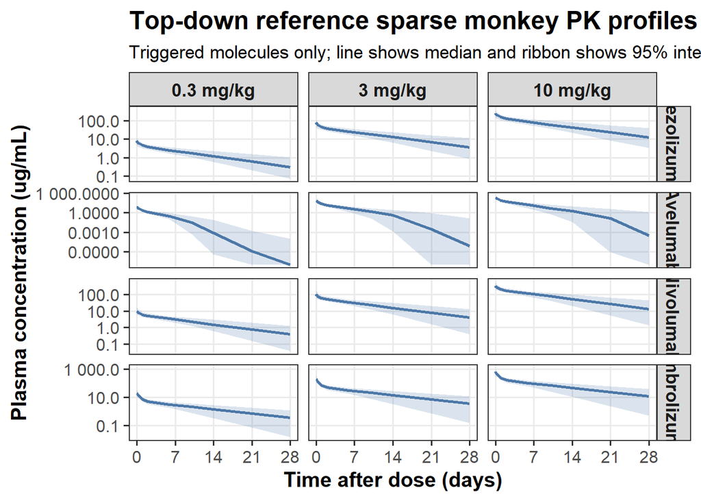

```r
qss_rxode_model <- rxode2::rxode({
  Ltot <- centr / vc
  Cp <- peri / vp
  free_drug <- 0.5 * ((Ltot - total_target - kss) +
    sqrt((Ltot - total_target - kss)^2 + 4 * kss * Ltot + 1e-12))
  complex <- Ltot - free_drug
  free_target <- total_target - complex

  d/dt(centr) = -cl * free_drug - q * free_drug + q * Cp -
    kint * complex * vc
  d/dt(peri) = q * free_drug - q * Cp
  d/dt(total_target) = ksyn - kdeg * free_target - kint * complex
})

simulate_topdown_profile <- function(parameter_row, dose_mgkg, times_h) {
  theta <- c(
    cl = parameter_row$CL_L_h_kg,
    vc = parameter_row$Vc_L_kg,
    q = parameter_row$Q_L_h_kg,
    vp = parameter_row$Vp_L_kg,
    r0 = parameter_row$Rtot_nM,
    kdeg = parameter_row$kdeg_h,
    kint = parameter_row$kint_h,
    kss = parameter_row$Kss_nM,
    ksyn = parameter_row$Rtot_nM * parameter_row$kdeg_h
  )

  event_table <- data.frame(
    id = parameter_row$IndividualId,
    time = c(0, times_h),
    amt = c(
      dose_mgkg_to_nmolkg(dose_mgkg, parameter_row$MW),
      rep(NA_real_, length(times_h))
    ),
    evid = c(1, rep(0, length(times_h))),
    cmt = "centr"
  )

  sol <- rxode2::rxSolve(
    qss_rxode_model,
    params = theta,
    events = event_table,
    inits = c(centr = 0, peri = 0, total_target = theta[["r0"]]),
    rtol = 1e-6,
    atol = 1e-9,
    hmin = 1e-12,
    maxsteps = 100000,
    returnType = "data.frame"
  ) %>%
    as_tibble()

  if ("evid" %in% names(sol)) {
    sol <- sol %>% filter(evid == 0 | is.na(evid))
  }

  sol %>%
    transmute(
      Scenario_name = paste(
        parameter_row$Drug, "Monkey", paste0("Dose", dose_mgkg), sep = "_"
      ),
      Drug = parameter_row$Drug,
      IndividualId = as.character(parameter_row$IndividualId),
      Dose_mgkg = dose_mgkg,
      Time_h = as.numeric(time),
      Time_day = Time_h / 24,
      Concentration_ug_mL = conc_nm_to_ug_ml(
        pmax(as.numeric(Ltot), 0),
        parameter_row$MW
      )
    )
}

topdown_sparse_profiles <- map_dfr(STUDY_DOSES, function(dose_mgkg) {
  map_dfr(
    seq_len(nrow(parameter_draws)),
    ~ simulate_topdown_profile(parameter_draws[.x, ], dose_mgkg, SPARSE_TIME_H)
  )
}) %>%
  group_by(Scenario_name, Drug, IndividualId, Dose_mgkg, Time_h, Time_day) %>%
  summarise(
    Concentration_ug_mL = mean(Concentration_ug_mL, na.rm = TRUE),
    .groups = "drop"
  )

topdown_sparse_auc <- topdown_sparse_profiles %>%
  group_by(Scenario_name, Drug, IndividualId, Dose_mgkg) %>%
  summarise(
    Sparse_AUC_ug_h_mL = linup_logdown_auc(
      c(0, Time_h),
      c(first(Concentration_ug_mL), Concentration_ug_mL)
    ),
    .groups = "drop"
  )

topdown_rich_profiles <- map_dfr(STUDY_DOSES, function(dose_mgkg) {
  map_dfr(
    seq_len(nrow(parameter_draws)),
    ~ simulate_topdown_profile(parameter_draws[.x, ], dose_mgkg, RICH_TIME_H)
  )
}) %>%
  group_by(Scenario_name, Drug, IndividualId, Dose_mgkg, Time_h, Time_day) %>%
  summarise(
    Concentration_ug_mL = mean(Concentration_ug_mL, na.rm = TRUE),
    .groups = "drop"
  )

topdown_rich_auc <- topdown_rich_profiles %>%
  group_by(Scenario_name, Drug, IndividualId, Dose_mgkg) %>%
  summarise(
    Rich_AUC_ug_h_mL = linup_logdown_auc(
      c(0, Time_h),
      c(first(Concentration_ug_mL), Concentration_ug_mL)
    ),
    .groups = "drop"
  )

stopifnot(
  nrow(topdown_sparse_auc) ==
    length(mabs_for_design) * length(STUDY_DOSES) * N_VIRTUAL,
  all(is.finite(topdown_sparse_auc$Sparse_AUC_ug_h_mL)),
  all(topdown_sparse_auc$Sparse_AUC_ug_h_mL > 0),
  nrow(topdown_rich_auc) ==
    length(mabs_for_design) * length(STUDY_DOSES) * N_VIRTUAL,
  all(is.finite(topdown_rich_auc$Rich_AUC_ug_h_mL)),
  all(topdown_rich_auc$Rich_AUC_ug_h_mL > 0)
)

write.csv(
  topdown_sparse_profiles,
  file.path(table_dir, "Gate2_topdown_sparse_profiles.csv"),
  row.names = FALSE
)
write.csv(
  topdown_sparse_auc,
  file.path(table_dir, "Gate2_topdown_sparse_AUC.csv"),
  row.names = FALSE
)
write.csv(
  topdown_rich_profiles,
  file.path(table_dir, "Gate2_topdown_rich_profiles.csv"),
  row.names = FALSE
)
write.csv(
  topdown_rich_auc,
  file.path(table_dir, "Gate2_topdown_rich_AUC.csv"),
  row.names = FALSE
)

profile_summary <- topdown_sparse_profiles %>%
  group_by(Drug, Dose_mgkg, Time_day) %>%
  summarise(
    Median_concentration_ug_mL = median(Concentration_ug_mL),
    PI95_lower_ug_mL = quantile(Concentration_ug_mL, 0.025),
    PI95_upper_ug_mL = quantile(Concentration_ug_mL, 0.975),
    .groups = "drop"
  ) %>%
  mutate(Dose_label = factor(
    paste0(Dose_mgkg, " mg/kg"),
    levels = paste0(STUDY_DOSES, " mg/kg")
  ))

profile_plot <- ggplot(
  profile_summary,
  aes(x = Time_day, y = pmax(Median_concentration_ug_mL, 1e-8))
) +
  geom_ribbon(
    aes(
      ymin = pmax(PI95_lower_ug_mL, 1e-8),
      ymax = pmax(PI95_upper_ug_mL, 1e-8)
    ),
    fill = "#4C78A8",
    alpha = 0.20
  ) +
  geom_line(color = "#4C78A8", linewidth = 1.0) +
  facet_grid(Drug ~ Dose_label, scales = "free_y") +
  scale_y_log10(labels = scales::label_number()) +
  scale_x_continuous(breaks = c(0, 7, 14, 21, 28), limits = c(0, 28)) +
  labs(
    x = "Time after dose (days)",
    y = "Plasma concentration (ug/mL)",
    title = "Top-down reference sparse monkey PK profiles",
    subtitle = "Triggered molecules only; line shows median and ribbon shows 95% interval"
  ) +
  STUDY_THEME

ggsave(
  file.path(figure_dir, "Gate2_topdown_sparse_profiles_triggered_molecules.png"),
  profile_plot,
  width = 9,
  height = 10,
  dpi = 300
)

profile_plot
```

## Reduced sparse-study adequacy

For each molecule, dose, and sample size, reduced studies are simulated by resampling `n` animals from the top-down reference population and calculating the study geometric mean sparse AUC. The reference is the geometric mean rich AUC from the full top-down virtual population (`n = 100`) across the three candidate dose levels. A simulated reduced study is successful if the sparse study geometric mean is within 2-fold of the full-population rich reference.

```r
reference_auc_summary <- topdown_rich_auc %>%
  group_by(Drug, Dose_mgkg) %>%
  summarise(
    Reference_AUC_mean_ug_h_mL = mean(Rich_AUC_ug_h_mL),
    Reference_AUC_median_ug_h_mL = median(Rich_AUC_ug_h_mL),
    Reference_AUC_geomean_ug_h_mL = geometric_mean(Rich_AUC_ug_h_mL),
    Reference_AUC_CV_percent =
      100 * sd(Rich_AUC_ug_h_mL) / mean(Rich_AUC_ug_h_mL),
    .groups = "drop"
  )

sparse_auc_lookup <- split(
  topdown_sparse_auc$Sparse_AUC_ug_h_mL,
  paste(topdown_sparse_auc$Drug, topdown_sparse_auc$Dose_mgkg, sep = "|")
)
reference_auc_lookup <- setNames(
  reference_auc_summary$Reference_AUC_geomean_ug_h_mL,
  paste(reference_auc_summary$Drug, reference_auc_summary$Dose_mgkg, sep = "|")
)

simulate_single_dose_reduced_study <- function(auc_values, n,
                                               reference,
                                               n_sim = N_SIM,
                                               fold = FOLD_ACCEPTANCE) {
  tibble(Replicate = seq_len(n_sim)) %>%
    mutate(
      Study_AUC_geomean_ug_h_mL = map_dbl(
        Replicate,
        ~ geometric_mean(sample(auc_values, n, replace = TRUE))
      ),
      Fold_error = Study_AUC_geomean_ug_h_mL / reference,
      Success_within_2fold =
        Fold_error >= 1 / fold & Fold_error <= fold
    )
}

single_dose_reduced_study_replicates <- crossing(
  topdown_sparse_auc %>% distinct(Drug, Dose_mgkg),
  N_per_group = N_PER_GROUP
) %>%
  mutate(
    Replicates = pmap(
      list(Drug, Dose_mgkg, N_per_group),
      ~ {
        lookup_key <- paste(..1, ..2, sep = "|")
        auc_values <- sparse_auc_lookup[[lookup_key]]
        reference <- reference_auc_lookup[[lookup_key]]
        simulate_single_dose_reduced_study(auc_values, ..3, reference)
      }
    )
  ) %>%
  unnest(Replicates)

single_dose_reduced_study_summary <-
  single_dose_reduced_study_replicates %>%
  group_by(Drug, Dose_mgkg, N_per_group) %>%
  summarise(
    Probability_within_2fold = mean(Success_within_2fold),
    Median_fold_error = median(Fold_error),
    Fold_error_5th_percentile = quantile(Fold_error, 0.05),
    Fold_error_95th_percentile = quantile(Fold_error, 0.95),
    .groups = "drop"
  ) %>%
  left_join(reference_auc_summary, by = c("Drug", "Dose_mgkg"))

write.csv(
  reference_auc_summary,
  file.path(table_dir, "Gate2_reference_AUC_CV_triggered_molecules.csv"),
  row.names = FALSE
)
write.csv(
  single_dose_reduced_study_summary,
  file.path(table_dir, "Gate2_single_dose_reduced_study_success.csv"),
  row.names = FALSE
)

single_dose_reduced_study_summary %>%
  kable(
    digits = 3,
    caption = paste0(
      "Reduced sparse-study adequacy by dose. Success is study geometric mean ",
      "AUC within ", FOLD_ACCEPTANCE,
      "-fold of the full top-down rich-population geometric mean AUC."
    )
  ) %>%
  kable_styling(bootstrap_options = c("striped", "condensed"),
                full_width = FALSE)
```

Reduced sparse-study adequacy by dose. Success is study geometric mean AUC within 2-fold of the full top-down rich-population geometric mean AUC.

| Drug | Dose_mgkg | N_per_group | Probability_within_2fold | Median_fold_error | Fold_error_5th_percentile | Fold_error_95th_percentile | Reference_AUC_mean_ug_h_mL | Reference_AUC_median_ug_h_mL | Reference_AUC_geomean_ug_h_mL | Reference_AUC_CV_percent |
| --- | --- | --- | --- | --- | --- | --- | --- | --- | --- | --- |
| Atezolizumab | 0.3 | 2 | 1.000 | 1.010 | 0.779 | 1.302 | 1110.941 | 1068.339 | 1085.951 | 21.776 |
| Atezolizumab | 0.3 | 3 | 1.000 | 1.013 | 0.819 | 1.243 | 1110.941 | 1068.339 | 1085.951 | 21.776 |
| Atezolizumab | 0.3 | 4 | 1.000 | 1.012 | 0.845 | 1.203 | 1110.941 | 1068.339 | 1085.951 | 21.776 |
| Atezolizumab | 0.3 | 5 | 1.000 | 1.001 | 0.857 | 1.165 | 1110.941 | 1068.339 | 1085.951 | 21.776 |
| Atezolizumab | 3.0 | 2 | 1.000 | 0.999 | 0.786 | 1.310 | 11603.890 | 11221.900 | 11345.817 | 21.791 |
| Atezolizumab | 3.0 | 3 | 1.000 | 0.994 | 0.824 | 1.226 | 11603.890 | 11221.900 | 11345.817 | 21.791 |
| Atezolizumab | 3.0 | 4 | 1.000 | 0.996 | 0.837 | 1.196 | 11603.890 | 11221.900 | 11345.817 | 21.791 |
| Atezolizumab | 3.0 | 5 | 1.000 | 0.996 | 0.861 | 1.164 | 11603.890 | 11221.900 | 11345.817 | 21.791 |
| Atezolizumab | 10.0 | 2 | 1.000 | 1.012 | 0.795 | 1.275 | 39133.020 | 37908.512 | 38270.511 | 21.723 |
| Atezolizumab | 10.0 | 3 | 1.000 | 1.003 | 0.829 | 1.236 | 39133.020 | 37908.512 | 38270.511 | 21.723 |
| Atezolizumab | 10.0 | 4 | 1.000 | 1.003 | 0.855 | 1.189 | 39133.020 | 37908.512 | 38270.511 | 21.723 |
| Atezolizumab | 10.0 | 5 | 1.000 | 1.006 | 0.863 | 1.170 | 39133.020 | 37908.512 | 38270.511 | 21.723 |
| Avelumab | 0.3 | 2 | 1.000 | 0.998 | 0.731 | 1.389 | 224.887 | 219.622 | 216.765 | 28.155 |
| Avelumab | 0.3 | 3 | 1.000 | 1.009 | 0.777 | 1.300 | 224.887 | 219.622 | 216.765 | 28.155 |
| Avelumab | 0.3 | 4 | 1.000 | 1.003 | 0.810 | 1.239 | 224.887 | 219.622 | 216.765 | 28.155 |
| Avelumab | 0.3 | 5 | 1.000 | 0.998 | 0.837 | 1.219 | 224.887 | 219.622 | 216.765 | 28.155 |
| Avelumab | 3.0 | 2 | 1.000 | 1.008 | 0.745 | 1.413 | 2597.761 | 2507.424 | 2493.464 | 29.608 |
| Avelumab | 3.0 | 3 | 1.000 | 1.024 | 0.781 | 1.350 | 2597.761 | 2507.424 | 2493.464 | 29.608 |
| Avelumab | 3.0 | 4 | 1.000 | 1.015 | 0.805 | 1.291 | 2597.761 | 2507.424 | 2493.464 | 29.608 |
| Avelumab | 3.0 | 5 | 1.000 | 1.007 | 0.837 | 1.249 | 2597.761 | 2507.424 | 2493.464 | 29.608 |
| Avelumab | 10.0 | 2 | 0.999 | 1.006 | 0.728 | 1.401 | 8815.928 | 8468.593 | 8454.883 | 29.883 |
| Avelumab | 10.0 | 3 | 1.000 | 1.015 | 0.784 | 1.313 | 8815.928 | 8468.593 | 8454.883 | 29.883 |
| Avelumab | 10.0 | 4 | 1.000 | 1.004 | 0.804 | 1.272 | 8815.928 | 8468.593 | 8454.883 | 29.883 |
| Avelumab | 10.0 | 5 | 1.000 | 1.010 | 0.827 | 1.237 | 8815.928 | 8468.593 | 8454.883 | 29.883 |
| Nivolumab | 0.3 | 2 | 1.000 | 1.022 | 0.771 | 1.313 | 1495.415 | 1499.163 | 1458.774 | 22.162 |
| Nivolumab | 0.3 | 3 | 1.000 | 1.011 | 0.807 | 1.233 | 1495.415 | 1499.163 | 1458.774 | 22.162 |
| Nivolumab | 0.3 | 4 | 1.000 | 1.008 | 0.818 | 1.196 | 1495.415 | 1499.163 | 1458.774 | 22.162 |
| Nivolumab | 0.3 | 5 | 1.000 | 1.006 | 0.837 | 1.167 | 1495.415 | 1499.163 | 1458.774 | 22.162 |
| Nivolumab | 3.0 | 2 | 1.000 | 1.019 | 0.767 | 1.256 | 14983.778 | 15021.341 | 14616.206 | 22.177 |
| Nivolumab | 3.0 | 3 | 1.000 | 1.008 | 0.810 | 1.230 | 14983.778 | 15021.341 | 14616.206 | 22.177 |
| Nivolumab | 3.0 | 4 | 1.000 | 1.011 | 0.835 | 1.206 | 14983.778 | 15021.341 | 14616.206 | 22.177 |
| Nivolumab | 3.0 | 5 | 1.000 | 0.997 | 0.854 | 1.177 | 14983.778 | 15021.341 | 14616.206 | 22.177 |
| Nivolumab | 10.0 | 2 | 1.000 | 1.001 | 0.751 | 1.288 | 49954.420 | 50079.439 | 48728.915 | 22.178 |
| Nivolumab | 10.0 | 3 | 1.000 | 1.009 | 0.809 | 1.240 | 49954.420 | 50079.439 | 48728.915 | 22.178 |
| Nivolumab | 10.0 | 4 | 1.000 | 1.007 | 0.832 | 1.198 | 49954.420 | 50079.439 | 48728.915 | 22.178 |
| Nivolumab | 10.0 | 5 | 1.000 | 1.007 | 0.856 | 1.182 | 49954.420 | 50079.439 | 48728.915 | 22.178 |
| Pembrolizumab | 0.3 | 2 | 1.000 | 1.018 | 0.755 | 1.326 | 1486.406 | 1493.411 | 1446.946 | 23.000 |
| Pembrolizumab | 0.3 | 3 | 1.000 | 1.022 | 0.808 | 1.244 | 1486.406 | 1493.411 | 1446.946 | 23.000 |
| Pembrolizumab | 0.3 | 4 | 1.000 | 1.018 | 0.834 | 1.225 | 1486.406 | 1493.411 | 1446.946 | 23.000 |
| Pembrolizumab | 0.3 | 5 | 1.000 | 1.015 | 0.847 | 1.190 | 1486.406 | 1493.411 | 1446.946 | 23.000 |
| Pembrolizumab | 3.0 | 2 | 1.000 | 1.018 | 0.775 | 1.292 | 14873.000 | 14946.687 | 14477.715 | 23.012 |
| Pembrolizumab | 3.0 | 3 | 1.000 | 1.015 | 0.789 | 1.251 | 14873.000 | 14946.687 | 14477.715 | 23.012 |
| Pembrolizumab | 3.0 | 4 | 1.000 | 1.017 | 0.826 | 1.213 | 14873.000 | 14946.687 | 14477.715 | 23.012 |
| Pembrolizumab | 3.0 | 5 | 1.000 | 1.021 | 0.841 | 1.202 | 14873.000 | 14946.687 | 14477.715 | 23.012 |
| Pembrolizumab | 10.0 | 2 | 1.000 | 1.012 | 0.775 | 1.305 | 49579.006 | 49825.699 | 48261.189 | 23.013 |
| Pembrolizumab | 10.0 | 3 | 1.000 | 1.020 | 0.805 | 1.258 | 49579.006 | 49825.699 | 48261.189 | 23.013 |
| Pembrolizumab | 10.0 | 4 | 1.000 | 1.014 | 0.821 | 1.215 | 49579.006 | 49825.699 | 48261.189 | 23.013 |
| Pembrolizumab | 10.0 | 5 | 1.000 | 1.013 | 0.846 | 1.200 | 49579.006 | 49825.699 | 48261.189 | 23.013 |

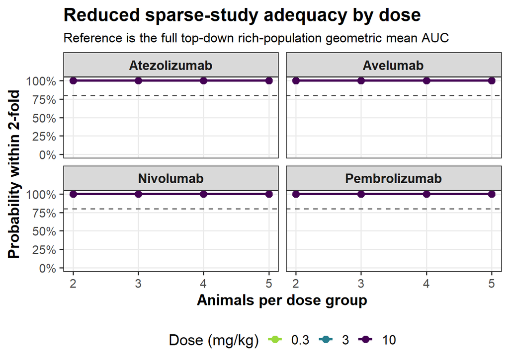

```r
single_dose_plot <- ggplot(
  single_dose_reduced_study_summary,
  aes(x = N_per_group, y = Probability_within_2fold,
      color = factor(Dose_mgkg), group = Dose_mgkg)
) +
  geom_hline(yintercept = 0.8, linetype = 2, color = "grey35") +
  geom_line(linewidth = 1.1) +
  geom_point(size = 2.8) +
  facet_wrap(~ Drug, ncol = 2) +
  scale_y_continuous(limits = c(0, 1), labels = scales::percent) +
  scale_x_continuous(breaks = N_PER_GROUP) +
  scale_color_viridis_d(option = "D", direction = -1, end = 0.85) +
  labs(
    x = "Animals per dose group",
    y = "Probability within 2-fold",
    color = "Dose (mg/kg)",
    title = "Reduced sparse-study adequacy by dose",
    subtitle = "Reference is the full top-down rich-population geometric mean AUC"
  ) +
  STUDY_THEME

ggsave(
  file.path(figure_dir, "Gate2_single_dose_reduced_study_success.png"),
  single_dose_plot,
  width = 10,
  height = 7,
  dpi = 300
)

single_dose_plot
```

## Two- and three-dose reduced study designs

The dose-design analysis is stricter than the single-dose analysis. A simulated design replicate is successful only if every selected dose group is within 2-fold of its corresponding full-population top-down rich AUC reference.

```r
simulate_design_replicate <- function(drug, doses, n_by_dose,
                                      fold = FOLD_ACCEPTANCE) {
  dose_success <- logical(length(doses))

  for (i in seq_along(doses)) {
    lookup_key <- paste(drug, doses[i], sep = "|")
    auc_values <- sparse_auc_lookup[[lookup_key]]
    reference <- reference_auc_lookup[[lookup_key]]
    study_gmean <- geometric_mean(sample(auc_values, n_by_dose[i], replace = TRUE))
    dose_success[i] <- within_fold(study_gmean, reference, fold)
  }

  all(dose_success)
}

simulate_design_success <- function(drug, doses, n_by_dose,
                                    n_sim = N_SIM) {
  mean(replicate(
    n_sim,
    simulate_design_replicate(drug, doses, n_by_dose)
  ))
}

design_success <- crossing(
  Drug = mabs_for_design,
  Design = names(DESIGN_DOSES),
  N_per_group = N_PER_GROUP
) %>%
  mutate(
    Number_of_dose_groups = lengths(DESIGN_DOSES[Design]),
    Total_animals = Number_of_dose_groups * N_per_group,
    Probability_within_2fold = pmap_dbl(
      list(Drug, Design, N_per_group),
      ~ {
        doses <- DESIGN_DOSES[[..2]]
        simulate_design_success(..1, doses, rep(..3, length(doses)))
      }
    ),
    Probability_per_animal = Probability_within_2fold / Total_animals
  )

write.csv(
  design_success,
  file.path(table_dir, "Gate2_two_vs_three_dose_design_success.csv"),
  row.names = FALSE
)

design_success %>%
  kable(
    digits = 3,
    caption = paste0(
      "Two- versus three-dose reduced sparse-study designs. Success requires ",
      "all selected dose groups to estimate top-down rich AUC within ",
      FOLD_ACCEPTANCE, "-fold."
    )
  ) %>%
  kable_styling(bootstrap_options = c("striped", "condensed"),
                full_width = FALSE)
```

Two- versus three-dose reduced sparse-study designs. Success requires all selected dose groups to estimate top-down rich AUC within 2-fold.

| Drug | Design | N_per_group | Number_of_dose_groups | Total_animals | Probability_within_2fold | Probability_per_animal |
| --- | --- | --- | --- | --- | --- | --- |
| Atezolizumab | 2 dose groups | 2 | 2 | 4 | 1 | 0.250 |
| Atezolizumab | 2 dose groups | 3 | 2 | 6 | 1 | 0.167 |
| Atezolizumab | 2 dose groups | 4 | 2 | 8 | 1 | 0.125 |
| Atezolizumab | 2 dose groups | 5 | 2 | 10 | 1 | 0.100 |
| Atezolizumab | 3 dose groups | 2 | 3 | 6 | 1 | 0.167 |
| Atezolizumab | 3 dose groups | 3 | 3 | 9 | 1 | 0.111 |
| Atezolizumab | 3 dose groups | 4 | 3 | 12 | 1 | 0.083 |
| Atezolizumab | 3 dose groups | 5 | 3 | 15 | 1 | 0.067 |
| Avelumab | 2 dose groups | 2 | 2 | 4 | 1 | 0.250 |
| Avelumab | 2 dose groups | 3 | 2 | 6 | 1 | 0.167 |
| Avelumab | 2 dose groups | 4 | 2 | 8 | 1 | 0.125 |
| Avelumab | 2 dose groups | 5 | 2 | 10 | 1 | 0.100 |
| Avelumab | 3 dose groups | 2 | 3 | 6 | 1 | 0.167 |
| Avelumab | 3 dose groups | 3 | 3 | 9 | 1 | 0.111 |
| Avelumab | 3 dose groups | 4 | 3 | 12 | 1 | 0.083 |
| Avelumab | 3 dose groups | 5 | 3 | 15 | 1 | 0.067 |
| Nivolumab | 2 dose groups | 2 | 2 | 4 | 1 | 0.250 |
| Nivolumab | 2 dose groups | 3 | 2 | 6 | 1 | 0.167 |
| Nivolumab | 2 dose groups | 4 | 2 | 8 | 1 | 0.125 |
| Nivolumab | 2 dose groups | 5 | 2 | 10 | 1 | 0.100 |
| Nivolumab | 3 dose groups | 2 | 3 | 6 | 1 | 0.167 |
| Nivolumab | 3 dose groups | 3 | 3 | 9 | 1 | 0.111 |
| Nivolumab | 3 dose groups | 4 | 3 | 12 | 1 | 0.083 |
| Nivolumab | 3 dose groups | 5 | 3 | 15 | 1 | 0.067 |
| Pembrolizumab | 2 dose groups | 2 | 2 | 4 | 1 | 0.250 |
| Pembrolizumab | 2 dose groups | 3 | 2 | 6 | 1 | 0.167 |
| Pembrolizumab | 2 dose groups | 4 | 2 | 8 | 1 | 0.125 |
| Pembrolizumab | 2 dose groups | 5 | 2 | 10 | 1 | 0.100 |
| Pembrolizumab | 3 dose groups | 2 | 3 | 6 | 1 | 0.167 |
| Pembrolizumab | 3 dose groups | 3 | 3 | 9 | 1 | 0.111 |
| Pembrolizumab | 3 dose groups | 4 | 3 | 12 | 1 | 0.083 |
| Pembrolizumab | 3 dose groups | 5 | 3 | 15 | 1 | 0.067 |

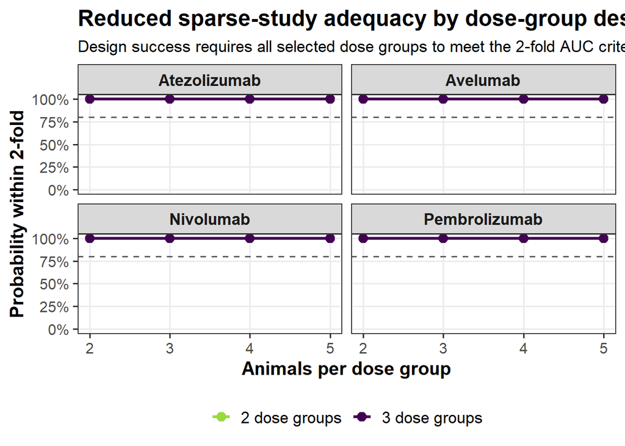

```r
design_success_plot <- ggplot(
  design_success,
  aes(x = N_per_group, y = Probability_within_2fold,
      color = Design, group = Design)
) +
  geom_hline(yintercept = 0.8, linetype = 2, color = "grey35") +
  geom_line(linewidth = 1.2) +
  geom_point(size = 3) +
  facet_wrap(~ Drug, ncol = 2) +
  scale_y_continuous(limits = c(0, 1), labels = scales::percent) +
  scale_x_continuous(breaks = N_PER_GROUP) +
  scale_color_viridis_d(option = "D", direction = -1, end = 0.85) +
  labs(
    x = "Animals per dose group",
    y = "Probability within 2-fold",
    color = NULL,
    title = "Reduced sparse-study adequacy by dose-group design",
    subtitle = "Design success requires all selected dose groups to meet the 2-fold AUC criterion"
  ) +
  STUDY_THEME

ggsave(
  file.path(figure_dir, "Gate2_two_vs_three_dose_design_success.png"),
  design_success_plot,
  width = 10,
  height = 7,
  dpi = 300
)

design_success_plot
```

## Design-level fold-error visualization

For manuscript presentation, the most direct visualization is the distribution of the design-level worst-case fold error. This compares the two- and three-dose reduced designs with 2-5 animals per dose group. Each replicate samples animals at each dose, compares the study geometric mean AUC with the full top-down rich-population geometric mean AUC for that dose, and records the worst symmetrized fold error across the selected dose groups.

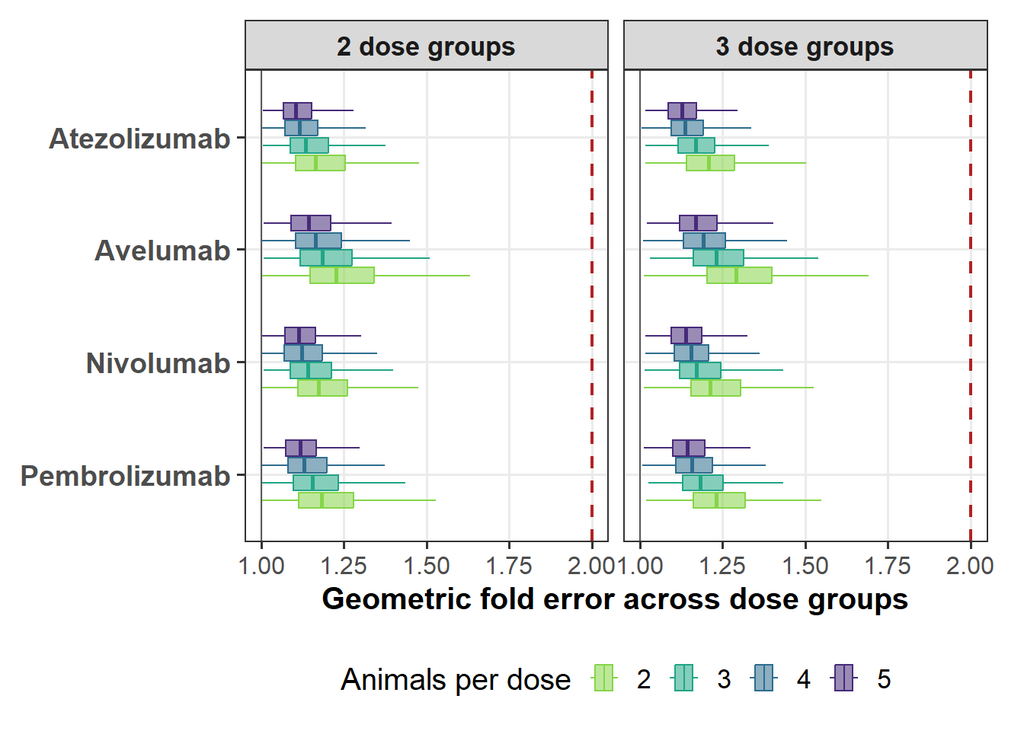

```r
simulate_design_fold_error_replicates <- function(drug,
                                                  design,
                                                  n_per_group = 2L,
                                                  n_sim = N_SIM) {
  doses <- DESIGN_DOSES[[design]]

  map_dfr(seq_len(n_sim), function(replicate_id) {
    dose_results <- map_dfr(doses, function(dose) {
      lookup_key <- paste(drug, dose, sep = "|")
      auc_values <- sparse_auc_lookup[[lookup_key]]
      reference <- reference_auc_lookup[[lookup_key]]
      study_gmean <- geometric_mean(
        sample(auc_values, n_per_group, replace = TRUE)
      )
      ratio <- study_gmean / reference
      tibble(
        Dose_mgkg = dose,
        Reference_AUC_geomean_ug_h_mL = reference,
        Study_AUC_geomean_ug_h_mL = study_gmean,
        Ratio_to_reference = ratio,
        Symmetric_fold_error = pmax(ratio, 1 / ratio)
      )
    })

    tibble(
      Drug = drug,
      Replicate = replicate_id,
      Design = design,
      N_per_group = n_per_group,
      Total_animals = length(doses) * n_per_group,
      Max_symmetric_fold_error = max(dose_results$Symmetric_fold_error),
      Success_within_2fold = Max_symmetric_fold_error <= FOLD_ACCEPTANCE
    )
  })
}

design_fold_error_replicates <- crossing(
  Drug = mabs_for_design,
  Design = names(DESIGN_DOSES),
  N_per_group = N_PER_GROUP
) %>%
  mutate(
    Replicates = pmap(
      list(Drug, Design, N_per_group),
      simulate_design_fold_error_replicates
    )
  ) %>%
  select(-Drug, -Design, -N_per_group) %>%
  unnest(Replicates) %>%
  mutate(
    Design = factor(Design, levels = names(DESIGN_DOSES)),
    N_per_group = factor(N_per_group, levels = N_PER_GROUP)
  )

sample_size_colors <- viridisLite::viridis(
  length(N_PER_GROUP),
  option = "D",
  direction = -1,
  begin = 0.12,
  end = 0.82
)

design_fold_error_summary <- design_fold_error_replicates %>%
  group_by(Drug, Design, N_per_group, Total_animals) %>%
  summarise(
    Probability_within_2fold = mean(Success_within_2fold),
    Median_max_symmetric_fold_error = median(Max_symmetric_fold_error),
    Fold_error_5th_percentile = quantile(Max_symmetric_fold_error, 0.05),
    Fold_error_95th_percentile = quantile(Max_symmetric_fold_error, 0.95),
    .groups = "drop"
  )

write.csv(
  design_fold_error_replicates,
  file.path(table_dir, "Gate2_design_fold_error_replicates_two_vs_three_dose_by_n.csv"),
  row.names = FALSE
)
write.csv(
  design_fold_error_summary,
  file.path(table_dir, "Gate2_design_fold_error_summary_two_vs_three_dose_by_n.csv"),
  row.names = FALSE
)

design_fold_error_plot <- ggplot(
  design_fold_error_replicates,
  aes(
    x = Max_symmetric_fold_error,
    y = fct_rev(factor(Drug)),
    fill = N_per_group,
    color = N_per_group
  )
) +
  geom_vline(xintercept = 1, color = "grey35", linewidth = 0.5) +
  geom_vline(
    xintercept = FOLD_ACCEPTANCE,
    color = "#B22222",
    linetype = 2,
    linewidth = 0.8
  ) +
  geom_boxplot(
    width = 0.62,
    outlier.shape = NA,
    alpha = 0.55,
    linewidth = 0.45,
    position = position_dodge2(width = 0.72, preserve = "single")
  ) +
  scale_x_continuous(
    limits = c(1, FOLD_ACCEPTANCE),
    breaks = c(1, 1.25, 1.5, 1.75, 2),
    labels = scales::label_number(accuracy = 0.01)
  ) +
  scale_fill_manual(values = sample_size_colors) +
  scale_color_manual(values = sample_size_colors) +
  facet_wrap(vars(Design), nrow = 1) +
  labs(
    x = "Geometric fold error across dose groups",
    y = NULL,
    fill = "Animals per dose",
    color = "Animals per dose"
  ) +
  STUDY_THEME +
  theme(
    legend.position = "bottom",
    plot.title = element_text(size = 17, face = "bold"),
    plot.subtitle = element_text(size = 13),
    axis.text.y = element_text(size = 14, face = "bold"),
    axis.text.x = element_text(size = 12),
    plot.caption = element_text(size = 10, hjust = 0),
    plot.margin = margin(10, 18, 10, 10)
  )

ggsave(
  file.path(figure_dir, "Gate2_design_fold_error_two_vs_three_dose_by_n_manuscript.png"),
  design_fold_error_plot,
  width = 13.5,
  height = 5.8,
  dpi = 450
)

design_fold_error_plot
```

## Manuscript-ready interpretation notes

```r
decision_table <- gate1_summary %>%
  mutate(
    Decision = if_else(
      Trigger_reduced_PK,
      "A priori AUC outside 2-fold for at least one dose: evaluate reduced sparse monkey PK study.",
      "A priori monkey AUC within 2-fold across available doses: reduced PK study may be confirmatory or unnecessary for PK characterization."
    )
  ) %>%
  left_join(
    design_success %>%
      group_by(Drug, Design) %>%
      filter(N_per_group == 3) %>%
      summarise(
        Probability_within_2fold_at_n3 = first(Probability_within_2fold),
        Total_animals_at_n3 = first(Total_animals),
        .groups = "drop"
      ) %>%
      pivot_wider(
        names_from = Design,
        values_from = c(Probability_within_2fold_at_n3, Total_animals_at_n3)
      ),
    by = "Drug"
  )

write.csv(
  decision_table,
  file.path(table_dir, "Two_gate_decision_summary.csv"),
  row.names = FALSE
)

decision_table %>%
  kable(
    digits = 3,
    caption = "Two-gate decision summary for manuscript interpretation."
  ) %>%
  kable_styling(bootstrap_options = c("striped", "condensed"),
                full_width = FALSE)
```

Two-gate decision summary for manuscript interpretation.

| Drug | AUC_dose_levels | AUC_levels_outside_2fold | Trigger_reduced_PK | Triggering_doses_mgkg | Decision | Probability_within_2fold_at_n3_2 dose groups | Probability_within_2fold_at_n3_3 dose groups | Total_animals_at_n3_2 dose groups | Total_animals_at_n3_3 dose groups |
| --- | --- | --- | --- | --- | --- | --- | --- | --- | --- |
| Adalimumab | 1 | 0 | FALSE |  | A priori monkey AUC within 2-fold across available doses: reduced PK study may be confirmatory or unnecessary for PK characterization. | NA | NA | NA | NA |
| Atezolizumab | 3 | 1 | TRUE | 0.5, 5, 20 | A priori AUC outside 2-fold for at least one dose: evaluate reduced sparse monkey PK study. | 1 | 1 | 6 | 9 |
| Avelumab | 1 | 1 | TRUE | 5 | A priori AUC outside 2-fold for at least one dose: evaluate reduced sparse monkey PK study. | 1 | 1 | 6 | 9 |
| Bevacizumab | 2 | 0 | FALSE |  | A priori monkey AUC within 2-fold across available doses: reduced PK study may be confirmatory or unnecessary for PK characterization. | NA | NA | NA | NA |
| Golimumab | 1 | 0 | FALSE |  | A priori monkey AUC within 2-fold across available doses: reduced PK study may be confirmatory or unnecessary for PK characterization. | NA | NA | NA | NA |
| Nivolumab | 2 | 1 | TRUE | 1, 10 | A priori AUC outside 2-fold for at least one dose: evaluate reduced sparse monkey PK study. | 1 | 1 | 6 | 9 |
| Pembrolizumab | 3 | 3 | TRUE | 0.3, 3, 30 | A priori AUC outside 2-fold for at least one dose: evaluate reduced sparse monkey PK study. | 1 | 1 | 6 | 9 |
| Tocilizumab | 1 | 0 | FALSE |  | A priori monkey AUC within 2-fold across available doses: reduced PK study may be confirmatory or unnecessary for PK characterization. | NA | NA | NA | NA |

Suggested manuscript text:

> We used a two-gate decision framework. First, a priori PBPK predictions were screened against observed monkey exposure. Molecules with at least one a priori AUC fold-error outside the 2-fold interval were considered cases where a reduced monkey PK study would be triggered. Second, for these triggered molecules, the observed-informed top-down monkey model was used as the retrospective reference for true monkey PK. Reduced sparse PK studies were simulated by sampling small groups of animals from the top-down virtual population and comparing the study geometric mean AUC with the full top-down population geometric mean AUC. This design separates model bias from sampling adequacy: failure of Gate 1 reflects limitations of the a priori prediction, whereas Gate 2 evaluates whether a reduced sparse monkey study is sufficient once in vivo PK characterization is needed.

> In this framework, increasing sample size is not expected to correct systematic a priori model bias. Instead, the reduced study simulation quantifies whether a targeted sparse monkey PK study can recover the observed-informed monkey exposure estimate with adequate precision, thereby supporting decisions about whether reduced in vivo PK data are sufficient for human trial initiation.